# DATA 607 - Project 2 - Data Transformation - Champions

Preston Peck

10/2/2021

# Load Libraries

```r
library(dplyr)
```

```r
library(jsonlite)
library(wordcloud)
library(RColorBrewer)
library(wordcloud2)
library(tm)
library(ggplot2)
```

# Import Data

The following is a dataset for attributes belonging to every character in the popular online multiplayer online battle arena game League of Legends

```r
leagueData <- fromJSON("data/champion.json")

leagueFormattedData <- matrix(NA, ncol = 27)
leagueFormattedData <- as.data.frame(leagueFormattedData)

colnames(leagueFormattedData) <- c(
  "name",
  "title",
  "blurb",
  "attack",
  "defense",
  "magic",
  "difficulty",
  "role1",
  "role2",
  "hp",
  "maxHp",
  "hpregen",
  "maxHpregen",
  "mp",
  "maxMp",
  "mpregen",
  "maxMpregen",
  "movespeed",
  "armor",
  "maxArmor",
  "spellblock",
  "maxSpellblock",
  "attackrange",
  "attackdamage",
  "maxAttackdamage",
  "attackspeed",
  "maxAttackspeed"
)

data <- leagueData[["data"]]
max <- length(data)

maxLevel <- 18

for (i in seq(from = 1, to = max - 1, by = 1)) {
  champion <- data[[i]]
  info <- champion[["info"]]
  stats <- champion[["stats"]]
  tags <- champion[["tags"]]

  leagueFormattedData <- leagueFormattedData %>%
    add_row(
      name = champion[["name"]],
      title = champion[["title"]],
      blurb = champion[["blurb"]],
      attack = as.numeric(info[["attack"]]),
      defense = as.numeric(info[["defense"]]),
      magic = as.numeric(info[["magic"]]),
      difficulty = as.numeric(info[["difficulty"]]),
      role1 = tags[1],
      role2 = tags[2],
      hp = as.numeric(stats[["hp"]]),
      maxHp = as.numeric(stats[["hp"]]) + as.numeric(stats[["hpperlevel"]]) * maxLevel,
      hpregen = as.numeric(stats[["hpregen"]]),
      maxHpregen = as.numeric(stats[["hpregen"]]) + as.numeric(stats[["hpregenperlevel"]]) * maxLevel,
      mp = as.numeric(stats[["mp"]]),
      maxMp = as.numeric(stats[["mp"]]) + as.numeric(stats[["mpperlevel"]]) * maxLevel,
      mpregen = as.numeric(stats[["mpregen"]]),
      maxMpregen = as.numeric(stats[["mpregen"]]) + as.numeric(stats[["mpregenperlevel"]]) * maxLevel,
      movespeed = as.numeric(stats[["movespeed"]]),
      armor = as.numeric(stats[["armor"]]),
      maxArmor = as.numeric(stats[["armor"]]) + as.numeric(stats[["armorperlevel"]]) * maxLevel,
      spellblock = as.numeric(stats[["spellblock"]]),
      maxSpellblock = as.numeric(stats[["spellblock"]]) + as.numeric(stats[["spellblockperlevel"]]) * maxLevel,
      attackrange = as.numeric(stats[["attackrange"]]),
      attackdamage = as.numeric(stats[["attackdamage"]]),
      maxAttackdamage = as.numeric(stats[["attackdamage"]]) + as.numeric(stats[["attackdamageperlevel"]]) * maxLevel,
      attackspeed = as.numeric(stats[["attackspeed"]]),
      maxAttackspeed = as.numeric(stats[["attackspeed"]]) + as.numeric(stats[["attackspeedperlevel"]]) * maxLevel
    )
}



# Remove NA row from matrix initialization
leagueFormattedData <- leagueFormattedData %>%
  slice(-c(1))

leagueFormattedData$baseTotal <-
  leagueFormattedData$hp +
  leagueFormattedData$mp +
  leagueFormattedData$hpregen +
  leagueFormattedData$mpregen +
  leagueFormattedData$movespeed +
  leagueFormattedData$armor +
  leagueFormattedData$spellblock +
  leagueFormattedData$attackrange +
  leagueFormattedData$attackdamage +
  leagueFormattedData$attackspeed

leagueFormattedData$maxTotal <-
  leagueFormattedData$maxHp +
  leagueFormattedData$maxMp +
  leagueFormattedData$maxHpregen +
  leagueFormattedData$maxMpregen +
  leagueFormattedData$movespeed +
  leagueFormattedData$maxArmor +
  leagueFormattedData$maxSpellblock +
  leagueFormattedData$attackrange +
  leagueFormattedData$maxAttackdamage +
  leagueFormattedData$maxAttackspeed

leagueFormattedData[,-3]
```

```
##               name                       title attack defense magic difficulty
## 1           Aatrox            the Darkin Blade      8       4     3          4
## 2             Ahri         the Nine-Tailed Fox      3       4     8          5
## 3            Akali          the Rogue Assassin      5       3     8          7
## 4           Akshan          the Rogue Sentinel      0       0     0          0
## 5          Alistar                the Minotaur      6       9     5          7
## 6            Amumu               the Sad Mummy      2       6     8          3
## 7           Anivia             the Cryophoenix      1       4    10         10
## 8            Annie              the Dark Child      2       3    10          6
## 9         Aphelios  the Weapon of the Faithful      6       2     1         10
## 10            Ashe            the Frost Archer      7       3     2          4
## 11    Aurelion Sol             The Star Forger      2       3     8          7
## 12            Azir    the Emperor of the Sands      6       3     8          9
## 13            Bard     the Wandering Caretaker      4       4     5          9
## 14      Blitzcrank       the Great Steam Golem      4       8     5          4
```

[output cut: 613 more lines]

```r
# Analyze blurbs to potentially identify writing style, genres, themes, and tropes
leagueFormattedData[,3]
```

```
##   [1] "Once honored defenders of Shurima against the Void, Aatrox and his brethren would eventually become an even greater threat to Runeterra, and were defeated only by cunning mortal sorcery. But after centuries of imprisonment, Aatrox was the first to find..."
##   [2] "Innately connected to the latent power of Runeterra, Ahri is a vastaya who can reshape magic into orbs of raw energy. She revels in toying with her prey by manipulating their emotions before devouring their life essence. Despite her predatory nature..."
##   [3] "Abandoning the Kinkou Order and her title of the Fist of Shadow, Akali now strikes alone, ready to be the deadly weapon her people need. Though she holds onto all she learned from her master Shen, she has pledged to defend Ionia from its enemies, one..."
##   [4] "Raising an eyebrow in the face of danger, Akshan fights evil with dashing charisma, righteous vengeance, and a conspicuous lack of shirts. He is highly skilled in the art of stealth combat, able to evade the eyes of his enemies and reappear when they..."
##   [5] "Always a mighty warrior with a fearsome reputation, Alistar seeks revenge for the death of his clan at the hands of the Noxian empire. Though he was enslaved and forced into the life of a gladiator, his unbreakable will was what kept him from truly..."
##   [6] "Legend claims that Amumu is a lonely and melancholy soul from ancient Shurima, roaming the world in search of a friend. Doomed by an ancient curse to remain alone forever, his touch is death, his affection ruin. Those who claim to have seen him describe..."
##   [7] "Anivia is a benevolent winged spirit who endures endless cycles of life, death, and rebirth to protect the Freljord. A demigod born of unforgiving ice and bitter winds, she wields those elemental powers to thwart any who dare disturb her homeland..."
##   [8] "Dangerous, yet disarmingly precocious, Annie is a child mage with immense pyromantic power. Even in the shadows of the mountains north of Noxus, she is a magical outlier. Her natural affinity for fire manifested early in life through unpredictable..."
##   [9] "Emerging from moonlight's shadow with weapons drawn, Aphelios kills the enemies of his faith in brooding silence—speaking only through the certainty of his aim, and the firing of each gun. Though fueled by a poison that renders him mute, he is guided by..."
##  [10] "Iceborn warmother of the Avarosan tribe, Ashe commands the most populous horde in the north. Stoic, intelligent, and idealistic, yet uncomfortable with her role as leader, she taps into the ancestral magics of her lineage to wield a bow of True Ice..."
##  [11] "Aurelion Sol once graced the vast emptiness of the cosmos with celestial wonders of his own devising. Now, he is forced to wield his awesome power at the behest of a space-faring empire that tricked him into servitude. Desiring a return to his..."
##  [12] "Azir was a mortal emperor of Shurima in a far distant age, a proud man who stood at the cusp of immortality. His hubris saw him betrayed and murdered at the moment of his greatest triumph, but now, millennia later, he has been reborn as an Ascended..."
##  [13] "A traveler from beyond the stars, Bard is an agent of serendipity who fights to maintain a balance where life can endure the indifference of chaos. Many Runeterrans sing songs that ponder his extraordinary nature, yet they all agree that the cosmic..."
##  [14] "Blitzcrank is an enormous, near-indestructible automaton from Zaun, originally built to dispose of hazardous waste. However, he found this primary purpose too restricting, and modified his own form to better serve the fragile people of the Sump..."
##  [15] "Once a tribesman of the icy Freljord named Kegan Rodhe, the creature known as Brand is a lesson in the temptation of greater power. Seeking one of the legendary World Runes, Kegan betrayed his companions and seized it for himself—and, in an instant, the..."
```

[output cut: 141 more lines]

```r
# Create a corpus
corpus <- Corpus(VectorSource(leagueFormattedData["blurb"]))

# Clean the text data (special characters, numbers, and punctuation) and avoid the most common frequent words
corpus <- corpus %>%
  tm_map(removeNumbers) %>%
  tm_map(removePunctuation) %>%
  tm_map(stripWhitespace)
corpus <- tm_map(corpus, content_transformer(tolower))
corpus <- tm_map(corpus, removeWords, stopwords("english"))

# Create a document-term-matrix
dtm <- TermDocumentMatrix(corpus)
matrix <- as.matrix(dtm)
words <- sort(rowSums(matrix), decreasing = TRUE)

df <- data.frame(word = names(words), freq = words)
greaterThan4Appearances <- subset(df, freq > 4)
greaterThan4Appearances
```

```
##                  word freq
## life             life   26
## ancient       ancient   22
## known           known   20
## power           power   20
## though         though   17
## even             even   16
## noxus           noxus   16
## one               one   16
## yordle         yordle   14
## many             many   13
## now               now   13
## shadow         shadow   13
## can               can   12
## city             city   12
## magic           magic   12
## shurima       shurima   12
## world           world   11
## magical       magical   10
## runeterra   runeterra   10
## spirit         spirit   10
## strength     strength   10
## death           death    9
## deep             deep    9
## mortal         mortal    9
## true             true    9
## void             void    9
## within         within    9
## zaun             zaun    9
## deadly         deadly    8
## demacia       demacia    8
## forced         forced    8
## ionian         ionian    8
## master         master    8
## order           order    8
## others         others    8
## powerful     powerful    8
## upon             upon    8
## warrior       warrior    8
## brutal         brutal    7
```

[output cut: 56 more lines]

```
## last             last    5
## long             long    5
## love             love    5
## mage             mage    5
## massive       massive    5
## nature         nature    5
## north           north    5
## perfect       perfect    5
## proud           proud    5
## souls           souls    5
## spirits       spirits    5
## targon         targon    5
## using           using    5
## will             will    5
## without       without    5
```

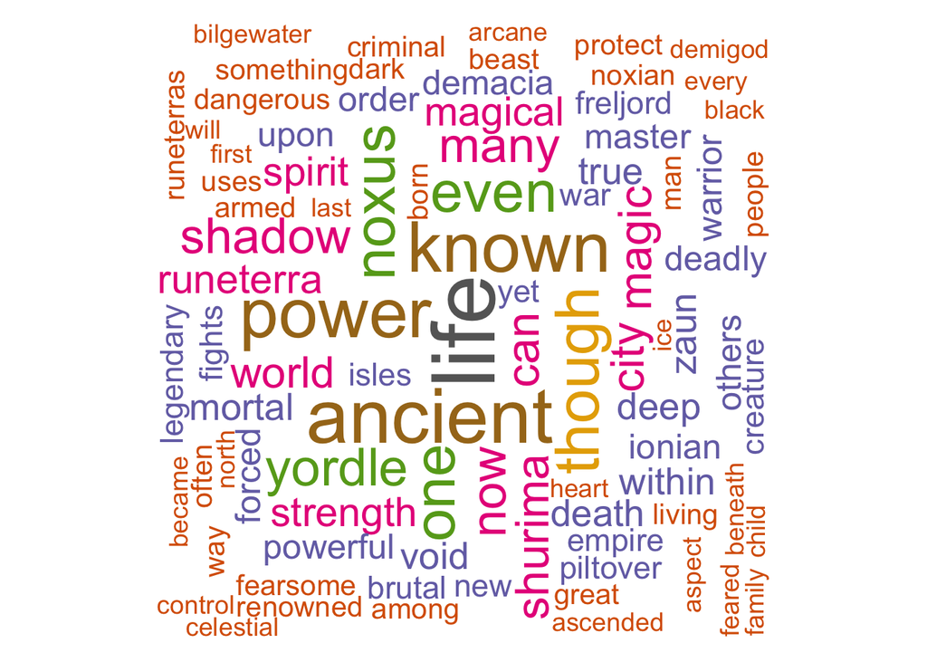

```r
# Generate the word cloud
wordcloud(words = df$word, freq = df$freq, min.freq = 5,
          max.words = 200, random.order = FALSE, rot.per = 0.35,
          colors = brewer.pal(8, "Dark2"))
```

```r
# Comparison between WordCloud 1 and 2
wordcloud2(data = greaterThan4Appearances, color='random-dark')
```

[interactive chart not shown]

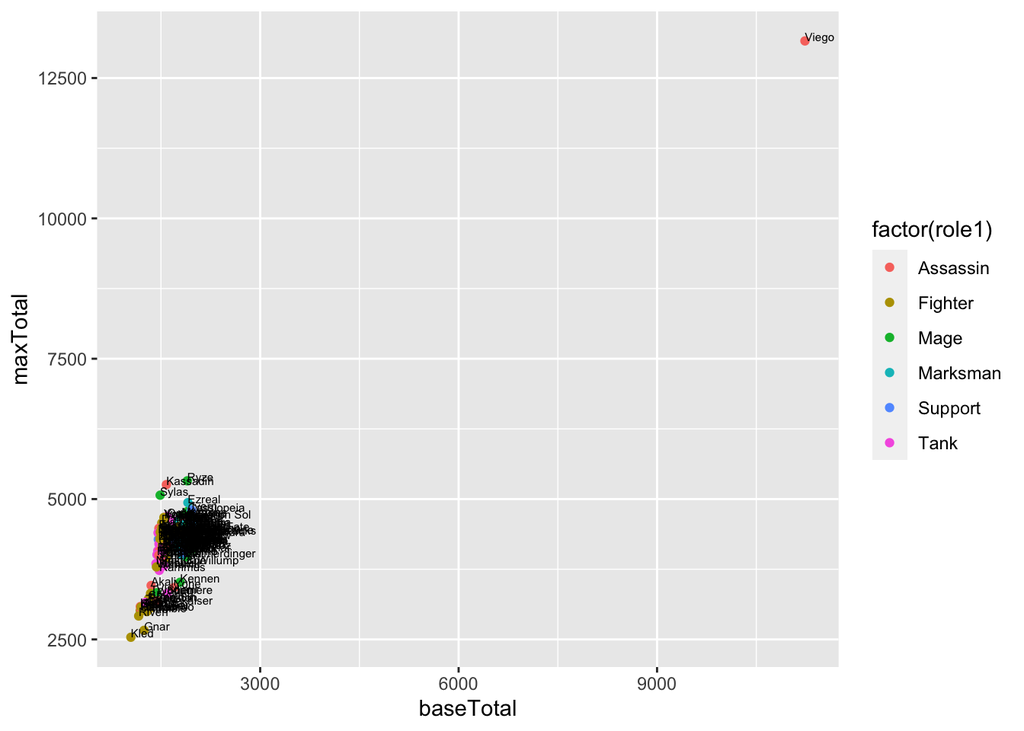

```r
ggplot(leagueFormattedData, aes(baseTotal, maxTotal)) +
  geom_point(aes(colour = factor(role1))) +
  geom_text(aes(label = name), hjust = 0, vjust = 0, , size = 2)
```

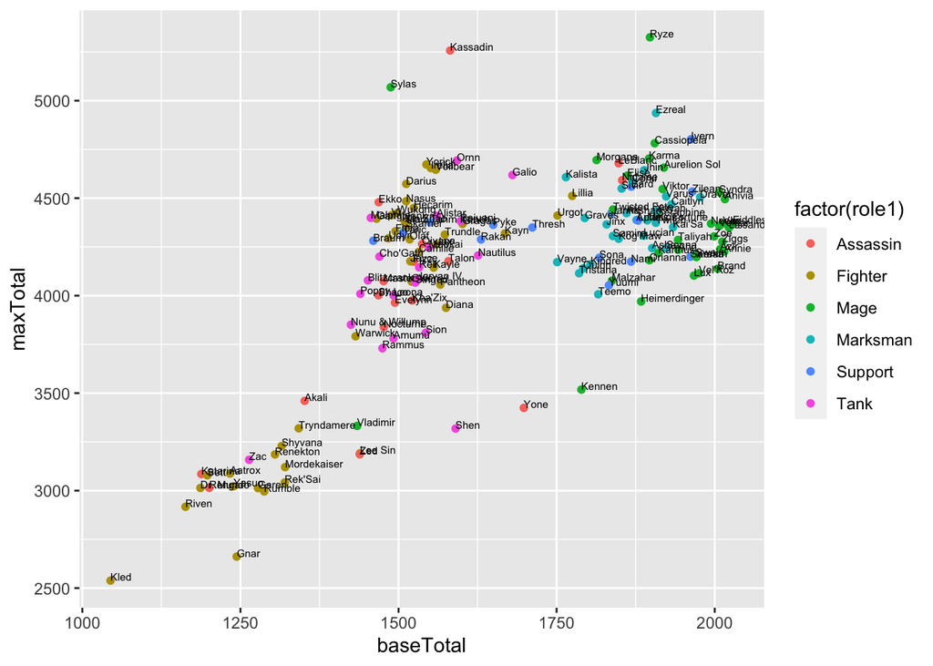

```r
removeOutlier <- subset(leagueFormattedData, name != "Viego")
ggplot(removeOutlier, aes(baseTotal, maxTotal)) +
  geom_point(aes(colour = factor(role1))) +
  geom_text(aes(label = name), hjust = 0, vjust = 0, size = 2)
```

# Analysis

In order to better understand the game and the demographics of its 156 characters in question, I looked at some of the popular language used to describe them. By doing so we’re not onlt able to determine not only the genre of the game, but also some of the tropes and archtypes used among its cast. We see alot of terms relating to magic (“arcane”) or spiritualism (“spirit”, “void”) indicating a fantasy setting. We also see words like “power”, “war”, and “city” which would point to many of the characters being military personnel in warring cities.

From a pure stat perpective, we can see which characters per role are good to use early-game vs late-game when we compare the culmination of their initial stats to the culmination of their stats given time. Doing so, there’s one clear outlier that stands out among the cast, which may mean that at any point they are a clear winning strategy, or that their stats are mistaken or grossly skewed for thematic instead of gameplay reasons.